# Cyclistic Bike-Share Case Study

Philemon John

2025-12-10

# Introduction

This project is the **Google Data Analytics Capstone Case Study**: *How does a bike-share navigate speedy success?*  
I applied the six-step data analysis process: **Ask, Prepare, Process, Analyze, Share, and Act**.

## 1. Ask Phase

### Business Task

To understand **how annual members and casual riders use Cyclistic bikes differently**, and design strategies to **convert casual riders into annual members**.

### Key Stakeholders

- **Cyclistic marketing team** – plans campaigns based on rider behavior.
- **Cyclistic executive team** – approves membership strategy.
- **Data analytics team** – supports data-driven decision-making.

## 2. Prepare Phase

### Data Source

The dataset comes from **Cyclistic’s trip data** made available by Motivate International Inc.  
It contains details of rides from the **past 12 months** and includes:

- Ride ID
- Bike type
- Start and end timestamps
- Station details (name, ID, latitude, longitude)
- User type (member or casual)

Data is publicly available and anonymized, ensuring privacy compliance.

```r
library(tidyverse)
library(lubridate)
library(janitor)
knitr::opts_chunk$set(echo = TRUE)
```

# Load all CSV files in ‘data’ folder

```r
all_trips <- list.files(path = "C:/data/Cyclistic_Project/data", pattern = "*.csv", full.names = TRUE) %>%
lapply(read_csv) %>%
bind_rows()
glimpse(all_trips)
```

```
## Rows: 5,539,521
## Columns: 13
## $ ride_id            <chr> "4422E707103AA4FF", "19DB722B44CBE82F", "20AE2509FD…
## $ rideable_type      <chr> "electric_bike", "electric_bike", "electric_bike", …
## $ started_at         <dttm> 2024-10-14 03:26:04, 2024-10-13 19:33:38, 2024-10-…
## $ ended_at           <dttm> 2024-10-14 03:32:56, 2024-10-13 19:39:04, 2024-10-…
## $ start_station_name <chr> NA, NA, NA, NA, NA, NA, NA, NA, NA, NA, NA, NA, NA,…
## $ start_station_id   <chr> NA, NA, NA, NA, NA, NA, NA, NA, NA, NA, NA, NA, NA,…
## $ end_station_name   <chr> NA, NA, NA, NA, NA, NA, NA, NA, NA, NA, NA, NA, NA,…
## $ end_station_id     <chr> NA, NA, NA, NA, NA, NA, NA, NA, NA, NA, NA, NA, NA,…
## $ start_lat          <dbl> 41.96, 41.98, 41.97, 41.95, 41.98, 41.88, 41.89, 41…
## $ start_lng          <dbl> -87.65, -87.67, -87.66, -87.65, -87.67, -87.65, -87…
## $ end_lat            <dbl> 41.98, 41.97, 41.95, 41.96, 41.98, 41.89, 41.88, 41…
## $ end_lng            <dbl> -87.67, -87.66, -87.65, -87.65, -87.67, -87.64, -87…
## $ member_casual      <chr> "member", "member", "member", "member", "member", "…
```

## 3.Process Phase

Data Cleaning

Steps performed:

2.Converted date-time columns to proper format.

3.Created new columns for ride length, day of week, month, and hour.

```r
# Read and clean data first
all_trips <- all_trips %>%
   # Step 1: make column names consistent
  mutate(
    started_at = as_datetime(started_at),
    ended_at = as_datetime(ended_at),
    ride_length = as.numeric(difftime(ended_at, started_at, units = "mins")),
    day_of_week = wday(started_at, label = TRUE),
    month = month(started_at, label = TRUE, abbr = FALSE),
    hour = hour(started_at)
  ) %>%
  filter(ride_length > 0) %>%
  clean_names()
```

4. Analyze Phase

We explored how ride duration, day of the week, and number of rides vary by user type.

4.1 Average Ride Duration by User Type

```r
avg_ride_length <- all_trips %>%
group_by(member_casual) %>%
summarise(mean_ride = mean(ride_length), median_ride = median(ride_length), max_ride = max(ride_length))

avg_ride_length
```

```
## # A tibble: 2 × 4
##   member_casual mean_ride median_ride max_ride
##   <chr>             <dbl>       <dbl>    <dbl>
## 1 casual             23.0       11.5     1575.
## 2 member             12.2        8.56    1500.
```

4.2 Average Ride Duration by Day of Week

```r
avg_ride_day <- all_trips %>%
group_by(member_casual, day_of_week) %>%
summarise(mean_ride = mean(ride_length), .groups = 'drop')

avg_ride_day
```

```
## # A tibble: 14 × 3
##    member_casual day_of_week mean_ride
##    <chr>         <ord>           <dbl>
##  1 casual        Sun              26.6
##  2 casual        Mon              22.5
##  3 casual        Tue              19.9
##  4 casual        Wed              19.2
##  5 casual        Thu              20.3
##  6 casual        Fri              22.8
##  7 casual        Sat              25.8
##  8 member        Sun              13.5
##  9 member        Mon              11.7
## 10 member        Tue              11.8
## 11 member        Wed              11.6
## 12 member        Thu              11.8
## 13 member        Fri              12.1
## 14 member        Sat              13.3
```

4.3 Number of Rides by Day of Week

```r
rides_per_day <- all_trips %>%
group_by(member_casual, day_of_week) %>%
summarise(number_of_rides = n(), .groups = 'drop')

rides_per_day
```

```
## # A tibble: 14 × 3
##    member_casual day_of_week number_of_rides
##    <chr>         <ord>                 <int>
##  1 casual        Sun                  338031
##  2 casual        Mon                  231883
##  3 casual        Tue                  232200
##  4 casual        Wed                  219831
##  5 casual        Thu                  251510
##  6 casual        Fri                  313602
##  7 casual        Sat                  409078
##  8 member        Sun                  391315
##  9 member        Mon                  509378
## 10 member        Tue                  578063
## 11 member        Wed                  541681
## 12 member        Thu                  557863
## 13 member        Fri                  517717
## 14 member        Sat                  447326
```

5. Share Phase

Visualization: Average Ride Duration

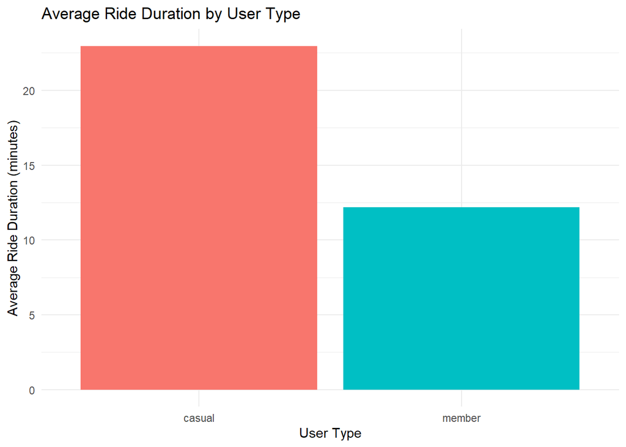

```r
ggplot(avg_ride_length, aes(x = member_casual, y = mean_ride, fill = member_casual)) +
geom_col(show.legend = FALSE) +
labs(title = "Average Ride Duration by User Type",
x = "User Type",
y = "Average Ride Duration (minutes)") +
theme_minimal()
```

Visualization: Number of Rides by Day of Week

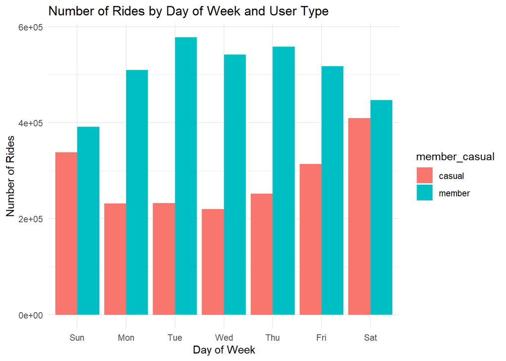

```r
ggplot(rides_per_day, aes(x = day_of_week, y = number_of_rides, fill = member_casual)) +
geom_col(position = "dodge") +
labs(title = "Number of Rides by Day of Week and User Type",
x = "Day of Week",
y = "Number of Rides") +
theme_minimal()
```

Visualization: Average Ride Duration by Day

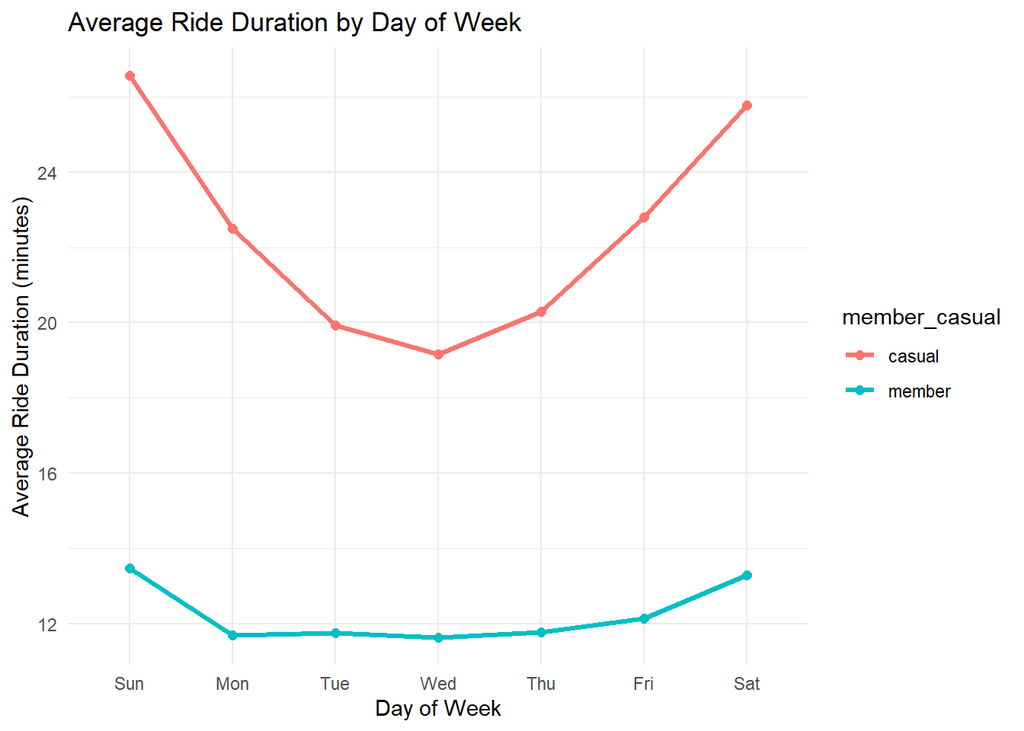

```r
ggplot(avg_ride_day, aes(x = day_of_week, y = mean_ride, color = member_casual, group = member_casual)) +
geom_line(size = 1.2) +
geom_point(size = 2) +
labs(title = "Average Ride Duration by Day of Week",
x = "Day of Week",
y = "Average Ride Duration (minutes)") +
theme_minimal()
```

6. Act Phase Key Findings

Casual riders have longer average ride times (≈ 23 mins) compared to members (≈ 12 mins).

Members ride more frequently, particularly on weekdays, indicating commute patterns.

Casual riders peak on weekends, suggesting leisure use.

Recommendations

Convert casuals to members via:

Weekend membership promotions.

Seasonal or tourist membership options.

Reward programs for repeated rides.

Corporate partnerships: Offer discounted memberships for employees.

In-app marketing: Show casual users their potential savings if they became members.

7. Conclusion

This analysis reveals clear behavioral patterns distinguishing casual riders from members. By leveraging these insights, Cyclistic can craft targeted marketing campaigns to boost membership and revenue.

8. Next Steps

Analyze station-level data to understand popular start and end locations.

Incorporate weather data to see its influence on riding behavior.

Build predictive models to forecast peak riding times.

Prepared by Philemon John Data Analyst